# Risk Factor Analysis

## Outcome Variable

**Outcome Variable:** wast_rec90d

## Predictor Variables

**Intervention Variable:** perdiar24

**Adjustment Set:**

unadjusted

## Stratifying Variables

The analysis was stratified on these variable(s):

- agecat
- studyid
- country

## Data Summary

| agecat | studyid | country | perdiar24 | wast_rec90d | n_cell | n |
| --- | --- | --- | --- | --- | --- | --- |
| 0-24 months | ki0047075b-MAL-ED | BANGLADESH | (0%, 5%] | 0 | 29 | 124 |
| 0-24 months | ki0047075b-MAL-ED | BANGLADESH | (0%, 5%] | 1 | 48 | 124 |
| 0-24 months | ki0047075b-MAL-ED | BANGLADESH | >5% | 0 | 13 | 124 |
| 0-24 months | ki0047075b-MAL-ED | BANGLADESH | >5% | 1 | 29 | 124 |
| 0-24 months | ki0047075b-MAL-ED | BANGLADESH | 0% | 0 | 3 | 124 |
| 0-24 months | ki0047075b-MAL-ED | BANGLADESH | 0% | 1 | 2 | 124 |
| 0-24 months | ki0047075b-MAL-ED | BRAZIL | (0%, 5%] | 0 | 3 | 23 |
| 0-24 months | ki0047075b-MAL-ED | BRAZIL | (0%, 5%] | 1 | 11 | 23 |
| 0-24 months | ki0047075b-MAL-ED | BRAZIL | >5% | 0 | 1 | 23 |
| 0-24 months | ki0047075b-MAL-ED | BRAZIL | >5% | 1 | 0 | 23 |
| 0-24 months | ki0047075b-MAL-ED | BRAZIL | 0% | 0 | 2 | 23 |
| 0-24 months | ki0047075b-MAL-ED | BRAZIL | 0% | 1 | 6 | 23 |
| 0-24 months | ki0047075b-MAL-ED | INDIA | (0%, 5%] | 0 | 54 | 178 |
| 0-24 months | ki0047075b-MAL-ED | INDIA | (0%, 5%] | 1 | 85 | 178 |
| 0-24 months | ki0047075b-MAL-ED | INDIA | >5% | 0 | 16 | 178 |
| 0-24 months | ki0047075b-MAL-ED | INDIA | >5% | 1 | 20 | 178 |
| 0-24 months | ki0047075b-MAL-ED | INDIA | 0% | 0 | 1 | 178 |
| 0-24 months | ki0047075b-MAL-ED | INDIA | 0% | 1 | 2 | 178 |
| 0-24 months | ki0047075b-MAL-ED | NEPAL | (0%, 5%] | 0 | 11 | 93 |
| 0-24 months | ki0047075b-MAL-ED | NEPAL | (0%, 5%] | 1 | 49 | 93 |
| 0-24 months | ki0047075b-MAL-ED | NEPAL | >5% | 0 | 6 | 93 |
| 0-24 months | ki0047075b-MAL-ED | NEPAL | >5% | 1 | 20 | 93 |
| 0-24 months | ki0047075b-MAL-ED | NEPAL | 0% | 0 | 3 | 93 |
| 0-24 months | ki0047075b-MAL-ED | NEPAL | 0% | 1 | 4 | 93 |
| 0-24 months | ki0047075b-MAL-ED | PERU | (0%, 5%] | 0 | 3 | 34 |
| 0-24 months | ki0047075b-MAL-ED | PERU | (0%, 5%] | 1 | 9 | 34 |
| 0-24 months | ki0047075b-MAL-ED | PERU | >5% | 0 | 3 | 34 |
| 0-24 months | ki0047075b-MAL-ED | PERU | >5% | 1 | 19 | 34 |
| 0-24 months | ki0047075b-MAL-ED | PERU | 0% | 0 | 0 | 34 |
| 0-24 months | ki0047075b-MAL-ED | PERU | 0% | 1 | 0 | 34 |

[output cut: 342 more lines]

The following strata were considered:

- agecat: 0-24 months, studyid: ki0047075b-MAL-ED, country: BANGLADESH
- agecat: 0-24 months, studyid: ki0047075b-MAL-ED, country: BRAZIL
- agecat: 0-24 months, studyid: ki0047075b-MAL-ED, country: INDIA
- agecat: 0-24 months, studyid: ki0047075b-MAL-ED, country: NEPAL
- agecat: 0-24 months, studyid: ki0047075b-MAL-ED, country: PERU
- agecat: 0-24 months, studyid: ki0047075b-MAL-ED, country: SOUTH AFRICA
- agecat: 0-24 months, studyid: ki0047075b-MAL-ED, country: TANZANIA, UNITED REPUBLIC OF
- agecat: 0-24 months, studyid: ki1000109-EE, country: PAKISTAN
- agecat: 0-24 months, studyid: ki1000109-ResPak, country: PAKISTAN
- agecat: 0-24 months, studyid: ki1000304b-SAS-FoodSuppl, country: INDIA
- agecat: 0-24 months, studyid: ki1017093-NIH-Birth, country: BANGLADESH
- agecat: 0-24 months, studyid: ki1017093b-PROVIDE, country: BANGLADESH
- agecat: 0-24 months, studyid: ki1017093c-NIH-Crypto, country: BANGLADESH
- agecat: 0-24 months, studyid: ki1112895-Guatemala BSC, country: GUATEMALA
- agecat: 0-24 months, studyid: ki1112895-iLiNS-Zinc, country: BURKINA FASO
- agecat: 0-24 months, studyid: ki1114097-CMIN, country: BANGLADESH
- agecat: 0-24 months, studyid: ki1114097-CMIN, country: BRAZIL
- agecat: 0-24 months, studyid: ki1114097-CMIN, country: GUINEA-BISSAU
- agecat: 0-24 months, studyid: ki1114097-CMIN, country: PERU
- agecat: 0-24 months, studyid: ki1114097-CONTENT, country: PERU
- agecat: 0-24 months, studyid: kiGH5241-JiVitA-4, country: BANGLADESH
- agecat: 0-6 months, studyid: ki0047075b-MAL-ED, country: BANGLADESH
- agecat: 0-6 months, studyid: ki0047075b-MAL-ED, country: BRAZIL
- agecat: 0-6 months, studyid: ki0047075b-MAL-ED, country: INDIA
- agecat: 0-6 months, studyid: ki0047075b-MAL-ED, country: NEPAL
- agecat: 0-6 months, studyid: ki0047075b-MAL-ED, country: PERU
- agecat: 0-6 months, studyid: ki0047075b-MAL-ED, country: SOUTH AFRICA
- agecat: 0-6 months, studyid: ki0047075b-MAL-ED, country: TANZANIA, UNITED REPUBLIC OF
- agecat: 0-6 months, studyid: ki1000109-EE, country: PAKISTAN
- agecat: 0-6 months, studyid: ki1000109-ResPak, country: PAKISTAN
- agecat: 0-6 months, studyid: ki1000304b-SAS-FoodSuppl, country: INDIA
- agecat: 0-6 months, studyid: ki1017093-NIH-Birth, country: BANGLADESH
- agecat: 0-6 months, studyid: ki1017093b-PROVIDE, country: BANGLADESH
- agecat: 0-6 months, studyid: ki1017093c-NIH-Crypto, country: BANGLADESH
- agecat: 0-6 months, studyid: ki1112895-Guatemala BSC, country: GUATEMALA
- agecat: 0-6 months, studyid: ki1114097-CMIN, country: BANGLADESH
- agecat: 0-6 months, studyid: ki1114097-CMIN, country: BRAZIL
- agecat: 0-6 months, studyid: ki1114097-CMIN, country: GUINEA-BISSAU
- agecat: 0-6 months, studyid: ki1114097-CMIN, country: PERU
- agecat: 0-6 months, studyid: ki1114097-CONTENT, country: PERU
- agecat: 0-6 months, studyid: kiGH5241-JiVitA-4, country: BANGLADESH
- agecat: 6-24 months, studyid: ki0047075b-MAL-ED, country: BANGLADESH
- agecat: 6-24 months, studyid: ki0047075b-MAL-ED, country: BRAZIL
- agecat: 6-24 months, studyid: ki0047075b-MAL-ED, country: INDIA
- agecat: 6-24 months, studyid: ki0047075b-MAL-ED, country: NEPAL
- agecat: 6-24 months, studyid: ki0047075b-MAL-ED, country: PERU
- agecat: 6-24 months, studyid: ki0047075b-MAL-ED, country: SOUTH AFRICA
- agecat: 6-24 months, studyid: ki0047075b-MAL-ED, country: TANZANIA, UNITED REPUBLIC OF
- agecat: 6-24 months, studyid: ki1000109-EE, country: PAKISTAN
- agecat: 6-24 months, studyid: ki1000109-ResPak, country: PAKISTAN
- agecat: 6-24 months, studyid: ki1000304b-SAS-FoodSuppl, country: INDIA
- agecat: 6-24 months, studyid: ki1017093-NIH-Birth, country: BANGLADESH
- agecat: 6-24 months, studyid: ki1017093b-PROVIDE, country: BANGLADESH
- agecat: 6-24 months, studyid: ki1017093c-NIH-Crypto, country: BANGLADESH
- agecat: 6-24 months, studyid: ki1112895-Guatemala BSC, country: GUATEMALA
- agecat: 6-24 months, studyid: ki1112895-iLiNS-Zinc, country: BURKINA FASO
- agecat: 6-24 months, studyid: ki1114097-CMIN, country: BANGLADESH
- agecat: 6-24 months, studyid: ki1114097-CMIN, country: BRAZIL
- agecat: 6-24 months, studyid: ki1114097-CMIN, country: GUINEA-BISSAU
- agecat: 6-24 months, studyid: ki1114097-CMIN, country: PERU
- agecat: 6-24 months, studyid: ki1114097-CONTENT, country: PERU
- agecat: 6-24 months, studyid: kiGH5241-JiVitA-4, country: BANGLADESH

### Dropped Strata

Some strata were dropped due to rare outcomes:

- agecat: 0-24 months, studyid: ki0047075b-MAL-ED, country: BANGLADESH
- agecat: 0-24 months, studyid: ki0047075b-MAL-ED, country: BRAZIL
- agecat: 0-24 months, studyid: ki0047075b-MAL-ED, country: INDIA
- agecat: 0-24 months, studyid: ki0047075b-MAL-ED, country: NEPAL
- agecat: 0-24 months, studyid: ki0047075b-MAL-ED, country: PERU
- agecat: 0-24 months, studyid: ki0047075b-MAL-ED, country: SOUTH AFRICA
- agecat: 0-24 months, studyid: ki0047075b-MAL-ED, country: TANZANIA, UNITED REPUBLIC OF
- agecat: 0-24 months, studyid: ki1000109-ResPak, country: PAKISTAN
- agecat: 0-24 months, studyid: ki1000304b-SAS-FoodSuppl, country: INDIA
- agecat: 0-24 months, studyid: ki1112895-Guatemala BSC, country: GUATEMALA
- agecat: 0-24 months, studyid: ki1112895-iLiNS-Zinc, country: BURKINA FASO
- agecat: 0-24 months, studyid: ki1114097-CMIN, country: BANGLADESH
- agecat: 0-24 months, studyid: ki1114097-CMIN, country: BRAZIL
- agecat: 0-24 months, studyid: ki1114097-CMIN, country: GUINEA-BISSAU
- agecat: 0-24 months, studyid: ki1114097-CMIN, country: PERU
- agecat: 0-24 months, studyid: ki1114097-CONTENT, country: PERU
- agecat: 0-6 months, studyid: ki0047075b-MAL-ED, country: BANGLADESH
- agecat: 0-6 months, studyid: ki0047075b-MAL-ED, country: BRAZIL
- agecat: 0-6 months, studyid: ki0047075b-MAL-ED, country: INDIA
- agecat: 0-6 months, studyid: ki0047075b-MAL-ED, country: NEPAL
- agecat: 0-6 months, studyid: ki0047075b-MAL-ED, country: PERU
- agecat: 0-6 months, studyid: ki0047075b-MAL-ED, country: SOUTH AFRICA
- agecat: 0-6 months, studyid: ki0047075b-MAL-ED, country: TANZANIA, UNITED REPUBLIC OF
- agecat: 0-6 months, studyid: ki1000109-EE, country: PAKISTAN
- agecat: 0-6 months, studyid: ki1000109-ResPak, country: PAKISTAN
- agecat: 0-6 months, studyid: ki1000304b-SAS-FoodSuppl, country: INDIA
- agecat: 0-6 months, studyid: ki1017093c-NIH-Crypto, country: BANGLADESH
- agecat: 0-6 months, studyid: ki1112895-Guatemala BSC, country: GUATEMALA
- agecat: 0-6 months, studyid: ki1114097-CMIN, country: BANGLADESH
- agecat: 0-6 months, studyid: ki1114097-CMIN, country: BRAZIL
- agecat: 0-6 months, studyid: ki1114097-CMIN, country: GUINEA-BISSAU
- agecat: 0-6 months, studyid: ki1114097-CMIN, country: PERU
- agecat: 0-6 months, studyid: ki1114097-CONTENT, country: PERU
- agecat: 6-24 months, studyid: ki0047075b-MAL-ED, country: BANGLADESH
- agecat: 6-24 months, studyid: ki0047075b-MAL-ED, country: BRAZIL
- agecat: 6-24 months, studyid: ki0047075b-MAL-ED, country: INDIA
- agecat: 6-24 months, studyid: ki0047075b-MAL-ED, country: NEPAL
- agecat: 6-24 months, studyid: ki0047075b-MAL-ED, country: PERU
- agecat: 6-24 months, studyid: ki0047075b-MAL-ED, country: SOUTH AFRICA
- agecat: 6-24 months, studyid: ki0047075b-MAL-ED, country: TANZANIA, UNITED REPUBLIC OF
- agecat: 6-24 months, studyid: ki1000109-EE, country: PAKISTAN
- agecat: 6-24 months, studyid: ki1000109-ResPak, country: PAKISTAN
- agecat: 6-24 months, studyid: ki1000304b-SAS-FoodSuppl, country: INDIA
- agecat: 6-24 months, studyid: ki1017093-NIH-Birth, country: BANGLADESH
- agecat: 6-24 months, studyid: ki1017093b-PROVIDE, country: BANGLADESH
- agecat: 6-24 months, studyid: ki1017093c-NIH-Crypto, country: BANGLADESH
- agecat: 6-24 months, studyid: ki1112895-Guatemala BSC, country: GUATEMALA
- agecat: 6-24 months, studyid: ki1112895-iLiNS-Zinc, country: BURKINA FASO
- agecat: 6-24 months, studyid: ki1114097-CMIN, country: BANGLADESH
- agecat: 6-24 months, studyid: ki1114097-CMIN, country: BRAZIL
- agecat: 6-24 months, studyid: ki1114097-CMIN, country: GUINEA-BISSAU
- agecat: 6-24 months, studyid: ki1114097-CMIN, country: PERU
- agecat: 6-24 months, studyid: ki1114097-CONTENT, country: PERU

## Methods Detail

We’re interested in the causal parameters $E[Y_a]$ for all values of $a \in \mathcal{A}$. These parameters represent the mean outcome if, possibly contrary to fact, we intervened to set all units to have $A=a$. Under the randomization and positivity assumptions, these are identified by the statistical parameters $\psi_a=E_W[E_{Y|A,W}(Y|A=a,W)]$. In addition, we’re interested in the mean of $Y$, $E[Y]$ under no intervention (the observed mean). We will estimate these parameters by using SuperLearner to fit the relevant likelihood factors – $E_{Y|A,W}(Y|A=a,W)$ and $p(A=a|W)$, and then updating our likelihood fit using a joint TMLE.

For unadjusted analyses ($W=\{\}$), initial likelihoods were estimated using Lrnr_glm to estimate the simple $E(Y|A)$ and Lrnr_mean to estimate $p(A)$. For adjusted analyses, a small library containing Lrnr_glmnet, Lrnr_xgboost, and Lrnr_mean was used.

Having estimated these parameters, we will then use the delta method to estimate relative risks and attributable risks relative to a prespecified baseline level of $A$.

# Results Detail

## Results Plots

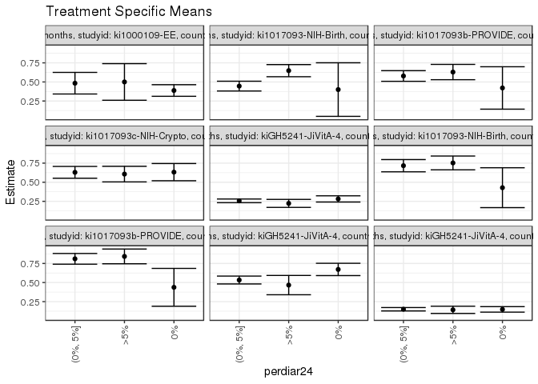

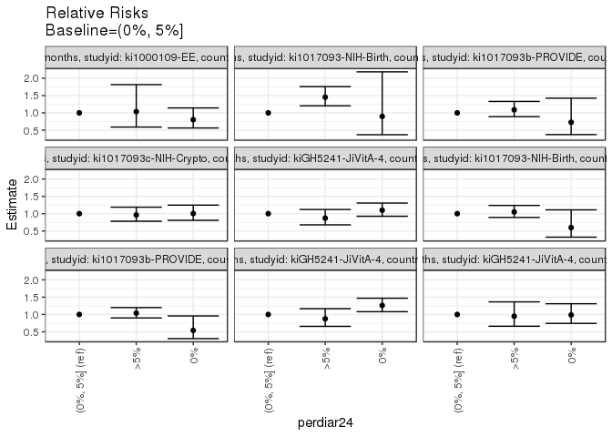

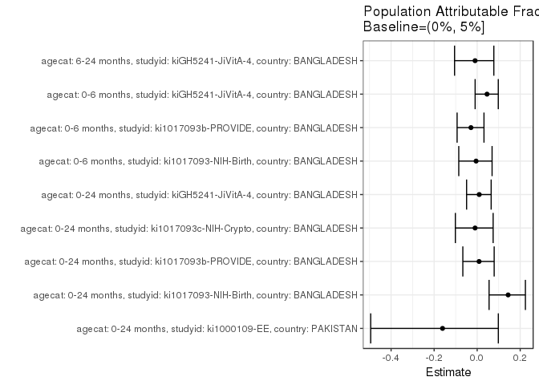

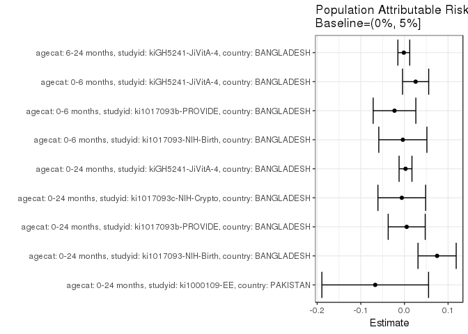

## Results Table

### Parameter: TSM

| agecat | studyid | country | intervention_level | baseline_level | estimate | ci_lower | ci_upper |
| --- | --- | --- | --- | --- | --- | --- | --- |
| 0-24 months | ki1000109-EE | PAKISTAN | (0%, 5%] | NA | 0.4833333 | 0.3417286 | 0.6249381 |
| 0-24 months | ki1000109-EE | PAKISTAN | >5% | NA | 0.5000000 | 0.2602715 | 0.7397285 |
| 0-24 months | ki1000109-EE | PAKISTAN | 0% | NA | 0.3879781 | 0.3120634 | 0.4638929 |
| 0-24 months | ki1017093-NIH-Birth | BANGLADESH | (0%, 5%] | NA | 0.4453441 | 0.3809000 | 0.5097883 |
| 0-24 months | ki1017093-NIH-Birth | BANGLADESH | >5% | NA | 0.6477987 | 0.5684298 | 0.7271677 |
| 0-24 months | ki1017093-NIH-Birth | BANGLADESH | 0% | NA | 0.4000000 | 0.0491643 | 0.7508357 |
| 0-24 months | ki1017093b-PROVIDE | BANGLADESH | (0%, 5%] | NA | 0.5778894 | 0.5082896 | 0.6474893 |
| 0-24 months | ki1017093b-PROVIDE | BANGLADESH | >5% | NA | 0.6292135 | 0.5290178 | 0.7294092 |
| 0-24 months | ki1017093b-PROVIDE | BANGLADESH | 0% | NA | 0.4210526 | 0.1434352 | 0.6986701 |
| 0-24 months | ki1017093c-NIH-Crypto | BANGLADESH | (0%, 5%] | NA | 0.6298701 | 0.5524797 | 0.7072606 |
| 0-24 months | ki1017093c-NIH-Crypto | BANGLADESH | >5% | NA | 0.6067416 | 0.5046515 | 0.7088317 |
| 0-24 months | ki1017093c-NIH-Crypto | BANGLADESH | 0% | NA | 0.6323529 | 0.5194878 | 0.7452181 |
| 0-24 months | kiGH5241-JiVitA-4 | BANGLADESH | (0%, 5%] | NA | 0.2560976 | 0.2319938 | 0.2802013 |
| 0-24 months | kiGH5241-JiVitA-4 | BANGLADESH | >5% | NA | 0.2231405 | 0.1709103 | 0.2753707 |
| 0-24 months | kiGH5241-JiVitA-4 | BANGLADESH | 0% | NA | 0.2815534 | 0.2409360 | 0.3221708 |
| 0-6 months | ki1017093-NIH-Birth | BANGLADESH | (0%, 5%] | NA | 0.7166667 | 0.6364129 | 0.7969204 |
| 0-6 months | ki1017093-NIH-Birth | BANGLADESH | >5% | NA | 0.7528090 | 0.6625804 | 0.8430376 |
| 0-6 months | ki1017093-NIH-Birth | BANGLADESH | 0% | NA | 0.4285714 | 0.1675904 | 0.6895524 |
| 0-6 months | ki1017093b-PROVIDE | BANGLADESH | (0%, 5%] | NA | 0.8108108 | 0.7405599 | 0.8810617 |
| 0-6 months | ki1017093b-PROVIDE | BANGLADESH | >5% | NA | 0.8421053 | 0.7456069 | 0.9386036 |
| 0-6 months | ki1017093b-PROVIDE | BANGLADESH | 0% | NA | 0.4375000 | 0.1897118 | 0.6852882 |
| 0-6 months | kiGH5241-JiVitA-4 | BANGLADESH | (0%, 5%] | NA | 0.5331492 | 0.4817093 | 0.5845891 |
| 0-6 months | kiGH5241-JiVitA-4 | BANGLADESH | >5% | NA | 0.4666667 | 0.3403187 | 0.5930146 |
| 0-6 months | kiGH5241-JiVitA-4 | BANGLADESH | 0% | NA | 0.6717557 | 0.5912717 | 0.7522398 |
| 6-24 months | kiGH5241-JiVitA-4 | BANGLADESH | (0%, 5%] | NA | 0.1505263 | 0.1283088 | 0.1727438 |
| 6-24 months | kiGH5241-JiVitA-4 | BANGLADESH | >5% | NA | 0.1428571 | 0.0955174 | 0.1901969 |
| 6-24 months | kiGH5241-JiVitA-4 | BANGLADESH | 0% | NA | 0.1484375 | 0.1124196 | 0.1844554 |

### Parameter: E(Y)

| agecat | studyid | country | intervention_level | baseline_level | estimate | ci_lower | ci_upper |
| --- | --- | --- | --- | --- | --- | --- | --- |
| 0-24 months | ki1000109-EE | PAKISTAN | NA | NA | 0.4163424 | 0.3511349 | 0.4815500 |
| 0-24 months | ki1017093-NIH-Birth | BANGLADESH | NA | NA | 0.5201900 | 0.4695846 | 0.5707955 |
| 0-24 months | ki1017093b-PROVIDE | BANGLADESH | NA | NA | 0.5830619 | 0.5262762 | 0.6398476 |
| 0-24 months | ki1017093c-NIH-Crypto | BANGLADESH | NA | NA | 0.6237942 | 0.5698223 | 0.6777662 |
| 0-24 months | kiGH5241-JiVitA-4 | BANGLADESH | NA | NA | 0.2585790 | 0.2392503 | 0.2779077 |
| 0-6 months | ki1017093-NIH-Birth | BANGLADESH | NA | NA | 0.7130045 | 0.6535890 | 0.7724200 |
| 0-6 months | ki1017093b-PROVIDE | BANGLADESH | NA | NA | 0.7880435 | 0.7295878 | 0.8464992 |
| 0-6 months | kiGH5241-JiVitA-4 | BANGLADESH | NA | NA | 0.5587703 | 0.5173487 | 0.6001920 |
| 6-24 months | kiGH5241-JiVitA-4 | BANGLADESH | NA | NA | 0.1490765 | 0.1314900 | 0.1666630 |

### Parameter: RR

| agecat | studyid | country | intervention_level | baseline_level | estimate | ci_lower | ci_upper |
| --- | --- | --- | --- | --- | --- | --- | --- |
| 0-24 months | ki1000109-EE | PAKISTAN | (0%, 5%] | (0%, 5%] | 1.0000000 | 1.0000000 | 1.0000000 |
| 0-24 months | ki1000109-EE | PAKISTAN | >5% | (0%, 5%] | 1.0344828 | 0.5897971 | 1.8144452 |
| 0-24 months | ki1000109-EE | PAKISTAN | 0% | (0%, 5%] | 0.8027134 | 0.5643474 | 1.1417592 |
| 0-24 months | ki1017093-NIH-Birth | BANGLADESH | (0%, 5%] | (0%, 5%] | 1.0000000 | 1.0000000 | 1.0000000 |
| 0-24 months | ki1017093-NIH-Birth | BANGLADESH | >5% | (0%, 5%] | 1.4546026 | 1.2034591 | 1.7581560 |
| 0-24 months | ki1017093-NIH-Birth | BANGLADESH | 0% | (0%, 5%] | 0.8981818 | 0.3692324 | 2.1848859 |
| 0-24 months | ki1017093b-PROVIDE | BANGLADESH | (0%, 5%] | (0%, 5%] | 1.0000000 | 1.0000000 | 1.0000000 |
| 0-24 months | ki1017093b-PROVIDE | BANGLADESH | >5% | (0%, 5%] | 1.0888129 | 0.8915479 | 1.3297249 |
| 0-24 months | ki1017093b-PROVIDE | BANGLADESH | 0% | (0%, 5%] | 0.7286041 | 0.3727394 | 1.4242230 |
| 0-24 months | ki1017093c-NIH-Crypto | BANGLADESH | (0%, 5%] | (0%, 5%] | 1.0000000 | 1.0000000 | 1.0000000 |
| 0-24 months | ki1017093c-NIH-Crypto | BANGLADESH | >5% | (0%, 5%] | 0.9632804 | 0.7818839 | 1.1867608 |
| 0-24 months | ki1017093c-NIH-Crypto | BANGLADESH | 0% | (0%, 5%] | 1.0039418 | 0.8081094 | 1.2472310 |
| 0-24 months | kiGH5241-JiVitA-4 | BANGLADESH | (0%, 5%] | (0%, 5%] | 1.0000000 | 1.0000000 | 1.0000000 |
| 0-24 months | kiGH5241-JiVitA-4 | BANGLADESH | >5% | (0%, 5%] | 0.8713105 | 0.6770274 | 1.1213461 |
| 0-24 months | kiGH5241-JiVitA-4 | BANGLADESH | 0% | (0%, 5%] | 1.0993990 | 0.9254309 | 1.3060707 |
| 0-6 months | ki1017093-NIH-Birth | BANGLADESH | (0%, 5%] | (0%, 5%] | 1.0000000 | 1.0000000 | 1.0000000 |
| 0-6 months | ki1017093-NIH-Birth | BANGLADESH | >5% | (0%, 5%] | 1.0504311 | 0.8915195 | 1.2376685 |
| 0-6 months | ki1017093-NIH-Birth | BANGLADESH | 0% | (0%, 5%] | 0.5980066 | 0.3219626 | 1.1107250 |
| 0-6 months | ki1017093b-PROVIDE | BANGLADESH | (0%, 5%] | (0%, 5%] | 1.0000000 | 1.0000000 | 1.0000000 |
| 0-6 months | ki1017093b-PROVIDE | BANGLADESH | >5% | (0%, 5%] | 1.0385965 | 0.8996136 | 1.1990511 |
| 0-6 months | ki1017093b-PROVIDE | BANGLADESH | 0% | (0%, 5%] | 0.5395833 | 0.3042456 | 0.9569577 |
| 0-6 months | kiGH5241-JiVitA-4 | BANGLADESH | (0%, 5%] | (0%, 5%] | 1.0000000 | 1.0000000 | 1.0000000 |
| 0-6 months | kiGH5241-JiVitA-4 | BANGLADESH | >5% | (0%, 5%] | 0.8753022 | 0.6566465 | 1.1667678 |
| 0-6 months | kiGH5241-JiVitA-4 | BANGLADESH | 0% | (0%, 5%] | 1.2599771 | 1.0803263 | 1.4695025 |
| 6-24 months | kiGH5241-JiVitA-4 | BANGLADESH | (0%, 5%] | (0%, 5%] | 1.0000000 | 1.0000000 | 1.0000000 |
| 6-24 months | kiGH5241-JiVitA-4 | BANGLADESH | >5% | (0%, 5%] | 0.9490509 | 0.6602722 | 1.3641309 |
| 6-24 months | kiGH5241-JiVitA-4 | BANGLADESH | 0% | (0%, 5%] | 0.9861233 | 0.7422924 | 1.3100486 |

### Parameter: PAR

| agecat | studyid | country | intervention_level | baseline_level | estimate | ci_lower | ci_upper |
| --- | --- | --- | --- | --- | --- | --- | --- |
| 0-24 months | ki1000109-EE | PAKISTAN | (0%, 5%] | NA | -0.0669909 | -0.1892589 | 0.0552771 |
| 0-24 months | ki1017093-NIH-Birth | BANGLADESH | (0%, 5%] | NA | 0.0748459 | 0.0310834 | 0.1186084 |
| 0-24 months | ki1017093b-PROVIDE | BANGLADESH | (0%, 5%] | NA | 0.0051724 | -0.0372625 | 0.0476074 |
| 0-24 months | ki1017093c-NIH-Crypto | BANGLADESH | (0%, 5%] | NA | -0.0060759 | -0.0607593 | 0.0486075 |
| 0-24 months | kiGH5241-JiVitA-4 | BANGLADESH | (0%, 5%] | NA | 0.0024815 | -0.0122754 | 0.0172383 |
| 0-6 months | ki1017093-NIH-Birth | BANGLADESH | (0%, 5%] | NA | -0.0036622 | -0.0587891 | 0.0514647 |
| 0-6 months | ki1017093b-PROVIDE | BANGLADESH | (0%, 5%] | NA | -0.0227673 | -0.0716489 | 0.0261142 |
| 0-6 months | kiGH5241-JiVitA-4 | BANGLADESH | (0%, 5%] | NA | 0.0256212 | -0.0043377 | 0.0555800 |
| 6-24 months | kiGH5241-JiVitA-4 | BANGLADESH | (0%, 5%] | NA | -0.0014498 | -0.0150329 | 0.0121333 |

### Parameter: PAF

| agecat | studyid | country | intervention_level | baseline_level | estimate | ci_lower | ci_upper |
| --- | --- | --- | --- | --- | --- | --- | --- |
| 0-24 months | ki1000109-EE | PAKISTAN | (0%, 5%] | NA | -0.1609034 | -0.4947222 | 0.0983631 |
| 0-24 months | ki1017093-NIH-Birth | BANGLADESH | (0%, 5%] | NA | 0.1438818 | 0.0553233 | 0.2241385 |
| 0-24 months | ki1017093b-PROVIDE | BANGLADESH | (0%, 5%] | NA | 0.0088712 | -0.0666177 | 0.0790174 |
| 0-24 months | ki1017093c-NIH-Crypto | BANGLADESH | (0%, 5%] | NA | -0.0097403 | -0.1013117 | 0.0742172 |
| 0-24 months | kiGH5241-JiVitA-4 | BANGLADESH | (0%, 5%] | NA | 0.0095965 | -0.0491397 | 0.0650444 |
| 0-6 months | ki1017093-NIH-Birth | BANGLADESH | (0%, 5%] | NA | -0.0051363 | -0.0855144 | 0.0692901 |
| 0-6 months | ki1017093b-PROVIDE | BANGLADESH | (0%, 5%] | NA | -0.0288910 | -0.0932132 | 0.0316467 |
| 0-6 months | kiGH5241-JiVitA-4 | BANGLADESH | (0%, 5%] | NA | 0.0458528 | -0.0094591 | 0.0981339 |
| 6-24 months | kiGH5241-JiVitA-4 | BANGLADESH | (0%, 5%] | NA | -0.0097252 | -0.1050859 | 0.0774066 |